# Episode 3: Working With Files and Directories

**Questions**

- How can I create, copy, and delete files and directories?
- How can I edit files?

**Objectives**

- Delete, copy and move specified files and/or directories.
- Create files in that hierarchy using an editor or by copying and renaming existing files.
- Create a directory hierarchy that matches a given diagram.

## Creating Directories

We now know how to explore files and directories, but how do we create them?

### Where Are We?

First, check where we are:

```bash
pwd
```

```
/Users/nelle/Desktop/shell-lesson-data
```

Move to `exercise-data/writing` and see what’s there:

```bash
cd exercise-data/writing/
ls -F
```

```
haiku.txt  LittleWomen.txt
```

## Creating a Directory

- Create a new directory called `thesis`:

```bash
mkdir thesis
```

`mkdir` means “make directory”

- Check it was created:

```bash
ls -F
```

```
haiku.txt  LittleWomen.txt  thesis/
```

- Verify the directory is empty (since we just created it):

```bash
ls -F thesis
```

No output means the directory is empty.

## Creating Nested Directories

The `-p` option creates nested subdirectories in one operation:

```bash
mkdir -p ../project/data ../project/results
```

Use `ls -FR` to recursively list the new hierarchy:

```bash
ls -FR ../project
```

```
../project/:
data/  results/

../project/data:

../project/results:
```

## Two Ways of Doing the Same Thing

**Note**

Using the shell to create a directory is no different than using a file explorer.

If you open the current directory using your operating system’s graphical file explorer, the `thesis` directory will appear there too.

The shell and the file explorer are two different ways of interacting with the files, but the files and directories themselves are the same.

## Good Names for Files and Directories

**Tip**

**Tips for naming files and directories:**

1. **Don’t use spaces** - Use `-` or `_` instead
   - Good: `north-pacific-gyre/`
   - Bad: `north pacific gyre/`
2. **Don’t begin with `-`** - Commands treat these as options
3. **Stick with:** lowercase letters, numbers, `.`, `-`, `_`
   - Many special characters have special meanings

## Spaces and Special Characters

- For names with spaces or special characters, wrap the name in quotes:

```bash
'my file with spaces.txt'
```

**Best practice:**

- Use all lowercase letters
- Windows and macOS are typically case insensitive
- Can’t distinguish between `thesis` and `Thesis` in same directory

## Creating a Text File

Change to `thesis` directory and create a file with `nano`:

```bash
cd thesis
nano draft.txt
```

`nano` is a simple text editor that runs in your terminal.

### Which Editor?

**Note**

`nano` is a text editor - it only works with plain character data.

**Other options:**

- Unix: [Emacs](https://www.gnu.org/software/emacs/), [Vim](https://www.vim.org/), [Gedit](https://projects.gnome.org/gedit/), [VSCode](https://code.visualstudio.com/)
- Windows: [Notepad++](https://notepad-plus-plus.org/), `notepad`

**Important:** Know where your editor searches for and saves files!

## Using nano

Type some text,

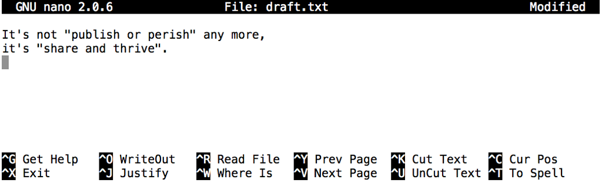

Then,

1. Press `Ctrl`+`O` to write data to disk
2. Press `Return` to accept filename `draft.txt`
3. Press `Ctrl`+`X` to quit and return to shell

## Verify File Creation

`nano` doesn’t leave output, but `ls` confirms the file exists:

```bash
ls
```

```
draft.txt
```

## Challenge

**Creating Files a Different Way**

Try this command:

```bash
touch my_file.txt
```

1. What did the `touch` command do? When you look at your current directory using the GUI file explorer, does the file show up?
2. Use `ls -l` to inspect the files. How large is `my_file.txt`?
3. When might you want to create a file this way?

## Solution

**Solution**

1. The `touch` command generates a new file called `my_file.txt` in your current directory. You can observe this newly generated file by typing `ls` at the command line prompt. `my_file.txt` can also be viewed in your GUI file explorer.
2. When you inspect the file with `ls -l`, note that the size of `my_file.txt` is 0 bytes. In other words, it contains no data. If you open `my_file.txt` using your text editor it is blank.
3. Some programs do not generate output files themselves, but instead require that empty files have already been generated. When the program is run, it searches for an existing file to populate with its output. The `touch` command allows you to efficiently generate a blank text file to be used by such programs.

To avoid confusion later on, we suggest removing the file you’ve just created before proceeding with the rest of the episode, otherwise future outputs may vary from those given in the lesson. To do this, use the following command:

```bash
rm my_file.txt
```

## What’s In A Name?

**Note**

Most file names are `something.extension`:

- `.txt` = plain text file
- `.pdf` = PDF document
- `.cfg` = configuration file
- `.png` = PNG image

**Important:** This is just a convention! Files contain bytes. Naming `whale.png` as `whale.mp3` doesn’t make it a sound file - it might just confuse programs trying to open it.

## Moving Files and Directories

Return to the `writing` directory:

```bash
cd ~/Desktop/shell-lesson-data/exercise-data/writing
```

`draft.txt` isn’t a very informative name. Let’s rename it using `mv`:

```bash
mv thesis/draft.txt thesis/quotes.txt
```

### How `mv` Works

`mv [old] [new]` moves or renames files

Check the result:

```bash
ls thesis
```

```
quotes.txt
```

**Warning:** `mv` will silently overwrite existing files with the same name!

Use `mv -i` or `mv --interactive` to ask for confirmation before overwriting.

## Moving to Current Directory

- Move `quotes.txt` to the current working directory:

```bash
mv thesis/quotes.txt .
```

The `.` means “current directory”

- Verify `thesis` is now empty:

```bash
ls thesis
```

```
$
```

- Try to list the file in `thesis`:

```bash
ls thesis/quotes.txt
```

```
ls: cannot access 'thesis/quotes.txt': No such file or directory
```

- Confirm it’s in current directory:

```bash
ls quotes.txt
```

```
quotes.txt
```

## Challenge

**Moving Files to a new folder**

After running the following commands, Jamie realizes that she put the files `sucrose.dat` and `maltose.dat` into the wrong folder. The files should have been placed in the `raw` folder.

```bash
ls -F
 analyzed/ raw/
ls -F analyzed
fructose.dat glucose.dat maltose.dat sucrose.dat
cd analyzed
```

Fill in the blanks to move these files to the `raw/` folder (i.e. the one she forgot to put them in)

```bash
mv sucrose.dat maltose.dat ____/____
```

## Solution

**Solution**

```bash
mv sucrose.dat maltose.dat ../raw
```

Recall that `..` refers to the parent directory (i.e. one above the current directory) and that `.` refers to the current directory.

## Copying Files and Directories

The `cp` command copies instead of moving:

```bash
cp quotes.txt thesis/quotations.txt
ls quotes.txt thesis/quotations.txt
```

```
quotes.txt   thesis/quotations.txt
```

`ls` can take multiple paths to show multiple files at once.

## Copying Directories

- Use the `-r` (recursive) option to copy directories:

```bash
cp -r thesis thesis_backup
```

- Check both directories:

```bash
ls thesis thesis_backup
```

```
thesis:
quotations.txt

thesis_backup:
quotations.txt
```

- If you omit `-r` when copying a directory:

```bash
cp thesis thesis_backup
```

```
cp: -r not specified; omitting directory 'thesis'
```

The `-r` flag is **required** to copy directories.

## Challenge

**Renaming Files**

Suppose that you created a plain-text file in your current directory to contain a list of the statistical tests you will need to do to analyze your data, and named it `statstics.txt`

After creating and saving this file you realize you misspelled the filename! You want to correct the mistake, which of the following commands could you use to do so?

1. `cp statstics.txt statistics.txt`
2. `mv statstics.txt statistics.txt`
3. `mv statstics.txt .`
4. `cp statstics.txt .`

## Solution

**Solution**

1. No. While this would create a file with the correct name, the incorrectly named file still exists in the directory and would need to be deleted.
2. Yes, this would work to rename the file.
3. No, the period(.) indicates where to move the file, but does not provide a new file name; identical file names cannot be created.
4. No, the period(.) indicates where to copy the file, but does not provide a new file name; identical file names cannot be created.

## Challenge

**Moving and Copying**

What is the output of the closing `ls` command in the sequence shown below?

```bash
pwd
```

```
/Users/jamie/data
```

```bash
ls
```

```
proteins.dat
```

```bash
mkdir recombined
mv proteins.dat recombined/
cp recombined/proteins.dat ../proteins-saved.dat
ls
```

1. `proteins-saved.dat recombined`
2. `recombined`
3. `proteins.dat recombined`
4. `proteins-saved.dat`

## Solution

**Solution**

We start in the `/Users/jamie/data` directory, and create a new folder called `recombined`. The second line moves (`mv`) the file `proteins.dat` to the new folder (`recombined`). The third line makes a copy of the file we just moved. The tricky part here is where the file was copied to. Recall that `..` means ‘go up a level’, so the copied file is now in `/Users/jamie`. Notice that `..` is interpreted with respect to the current working directory, **not** with respect to the location of the file being copied. So, the only thing that will show using ls (in `/Users/jamie/data`) is the recombined folder.

1. No, see explanation above. `proteins-saved.dat` is located at `/Users/jamie`
2. Yes
3. No, see explanation above. `proteins.dat` is located at `/Users/jamie/data/recombined`
4. No, see explanation above. `proteins-saved.dat` is located at `/Users/jamie`

## Removing Files and Directories

Return to the `writing` directory and remove `quotes.txt`:

```bash
rm quotes.txt
```

Confirm it’s gone:

```bash
ls quotes.txt
```

```
ls: cannot access 'quotes.txt': No such file or directory
```

**Deleting Is Forever**

**The Unix shell doesn’t have a trash bin!**

When we delete files, they are unlinked from the file system so their storage space can be recycled.

Tools for finding and recovering deleted files exist, but there’s no guarantee they’ll work - the computer may recycle the file’s disk space right away.

## Challenge

**Using `rm` Safely**

What happens when we execute `rm -i thesis_backup/quotations.txt`? Why would we want this protection when using `rm`?

## Solution

**Solution**

```
rm: remove regular file 'thesis_backup/quotations.txt'? y
```

The `-i` option will prompt before (every) removal (use `Y` to confirm deletion or `N` to keep the file). The Unix shell doesn’t have a trash bin, so all the files removed will disappear forever. By using the `-i` option, we have the chance to check that we are deleting only the files that we want to remove.

## Removing Directories

- If we try to remove a directory with just `rm`:

```bash
rm thesis
```

```
rm: cannot remove 'thesis': Is a directory
```

`rm` by default only works on files, not directories.

- Use `-r` (recursive) to remove a directory and all contents:

```bash
rm -r thesis
```

**⚠️ Warning:** This works without confirmation prompts!

Given that files can’t be retrieved, use `rm -r` with **great caution**.

Consider using `rm -r -i` for interactive confirmation.

## Operations with Multiple Files

Oftentimes we need to copy or move several files at once.

This can be done by:

- Providing a list of individual filenames
- Specifying a naming pattern using **wildcards**
- **Wildcards** represent unknown characters or character sets.

## Challenge

**Copy with Multiple Filenames**

For this exercise, you can test the commands in the `shell-lesson-data/exercise-data` directory.

We have seen how `cp` behaves when given two arguments, but `cp` behaves differently when given three or more arguments. Let’s try giving `cp` three arguments. In the example below, what does `cp` do when given several filenames and a directory name?

```bash
mkdir backup
cp creatures/minotaur.dat creatures/unicorn.dat backup/
```

In the example below, what does `cp` do when given three or more file names?

```bash
cd creatures
ls -F
```

```
basilisk.dat  minotaur.dat  unicorn.dat
```

```bash
cp minotaur.dat unicorn.dat basilisk.dat
```

## Solution

**Solution**

```
cp: target 'basilisk.dat' is not a directory
```

## Using Wildcards

**Note**

**`*` is a wildcard** - represents zero or more characters.

In `shell-lesson-data/exercise-data/alkanes`:

- `*.pdb` matches `ethane.pdb`, `propane.pdb`, and all files ending in `.pdb`
- `p*.pdb` only matches `pentane.pdb` and `propane.pdb`

**`?` is also a wildcard**

- represents exactly one character.
- `?ethane.pdb` matches `methane.pdb`
- `*ethane.pdb` matches `ethane.pdb` and `methane.pdb`

## Wildcards in Combination

Wildcards can be used together:

- `???ane.pdb` = three characters followed by `ane.pdb`
- Matches: `cubane.pdb`, `ethane.pdb`, `octane.pdb`

**How wildcards work:**

- The shell expands wildcards to matching filenames **before** running a command.

Exception: If no files match, Bash passes the expression as-is to the command.

## Challenge

**List filenames matching a pattern**

When run in the `alkanes` directory, which `ls` command(s) will produce this output?

`ethane.pdb methane.pdb`

1. `ls *t*ane.pdb`
2. `ls *t?ne.*`
3. `ls *t??ne.pdb`
4. `ls ethane.*`

## Solution

**Solution**

The solution is `3.`

`1.` shows all files whose names contain zero or more characters (`*`) followed by the letter `t`, then zero or more characters (`*`) followed by `ane.pdb`. This gives `ethane.pdb methane.pdb octane.pdb pentane.pdb`.

`2.` shows all files whose names start with zero or more characters (`*`) followed by the letter `t`, then a single character (`?`), then `ne.` followed by zero or more characters (`*`). This will give us `octane.pdb` and `pentane.pdb` but doesn’t match anything which ends in `thane.pdb`.

`3.` fixes the problems of option 2 by matching two characters (`??`) between `t` and `ne`. This is the solution.

`4.` only shows files starting with `ethane.`.

## Challenge

**More on Wildcards**

Sam has a directory containing calibration data, datasets, and descriptions of the datasets:

```bash
.
├── 2015-10-23-calibration.txt
├── 2015-10-23-dataset1.txt
├── 2015-10-23-dataset2.txt
├── 2015-10-23-dataset_overview.txt
├── 2015-10-26-calibration.txt
├── 2015-10-26-dataset1.txt
├── 2015-10-26-dataset2.txt
├── 2015-10-26-dataset_overview.txt
├── 2015-11-23-calibration.txt
├── 2015-11-23-dataset1.txt
├── 2015-11-23-dataset2.txt
├── 2015-11-23-dataset_overview.txt
├── backup
│   ├── calibration
│   └── datasets
└── send_to_bob
    ├── all_datasets_created_on_a_23rd
    └── all_november_files
```

Before heading off to another field trip, she wants to back up her data and send some datasets to her colleague Bob. Sam uses the following commands to get the job done:

```bash
cp *dataset* backup/datasets
cp ____calibration____ backup/calibration
cp 2015-____-____ send_to_bob/all_november_files/
cp ____ send_to_bob/all_datasets_created_on_a_23rd/
```

## Challenge

**More on Wildcards**

Help Sam by filling in the blanks.

The resulting directory structure should look like this

```bash
.
├── 2015-10-23-calibration.txt
├── 2015-10-23-dataset1.txt
├── 2015-10-23-dataset2.txt
├── 2015-10-23-dataset_overview.txt
├── 2015-10-26-calibration.txt
├── 2015-10-26-dataset1.txt
├── 2015-10-26-dataset2.txt
├── 2015-10-26-dataset_overview.txt
├── 2015-11-23-calibration.txt
├── 2015-11-23-dataset1.txt
├── 2015-11-23-dataset2.txt
├── 2015-11-23-dataset_overview.txt
├── backup
│   ├── calibration
│   │   ├── 2015-10-23-calibration.txt
│   │   ├── 2015-10-26-calibration.txt
│   │   └── 2015-11-23-calibration.txt
│   └── datasets
│       ├── 2015-10-23-dataset1.txt
│       ├── 2015-10-23-dataset2.txt
│       ├── 2015-10-23-dataset_overview.txt
│       ├── 2015-10-26-dataset1.txt
│       ├── 2015-10-26-dataset2.txt
│       ├── 2015-10-26-dataset_overview.txt
│       ├── 2015-11-23-dataset1.txt
│       ├── 2015-11-23-dataset2.txt
│       └── 2015-11-23-dataset_overview.txt
└── send_to_bob
    ├── all_datasets_created_on_a_23rd
    │   ├── 2015-10-23-dataset1.txt
    │   ├── 2015-10-23-dataset2.txt
    │   ├── 2015-10-23-dataset_overview.txt
    │   ├── 2015-11-23-dataset1.txt
    │   ├── 2015-11-23-dataset2.txt
    │   └── 2015-11-23-dataset_overview.txt
    └── all_november_files
        ├── 2015-11-23-calibration.txt
        ├── 2015-11-23-dataset1.txt
        ├── 2015-11-23-dataset2.txt
        └── 2015-11-23-dataset_overview.txt
```

## Solution

**Solution**

```bash
cp *calibration.txt backup/calibration
cp 2015-11-* send_to_bob/all_november_files/
cp *-23-dataset* send_to_bob/all_datasets_created_on_a_23rd/
```

## Challenge

**Organizing Directories and Files**

Jamie is working on a project, and she sees that her files aren’t very well organized:

```bash
ls -F
```

```
analyzed/  fructose.dat    raw/   sucrose.dat
```

The `fructose.dat` and `sucrose.dat` files contain output from her data analysis. What command(s) covered in this lesson does she need to run so that the commands below will produce the output shown?

```bash
ls -F
```

```
analyzed/   raw/
```

```bash
ls analyzed
```

```
fructose.dat    sucrose.dat
```

## Solution

**Solution**

```bash
mv *.dat analyzed
```

Jamie needs to move her files `fructose.dat` and `sucrose.dat` to the `analyzed` directory. The shell will expand *.dat to match all .dat files in the current directory. The `mv` command then moves the list of .dat files to the ‘analyzed’ directory.

## Challenge

**Reproduce a folder structure**

You’re starting a new experiment and would like to duplicate the directory structure from your previous experiment so you can add new data.

Assume that the previous experiment is in a folder called `2016-05-18`, which contains a `data` folder that in turn contains folders named `raw` and `processed` that contain data files. The goal is to copy the folder structure of the `2016-05-18` folder into a folder called `2016-05-20` so that your final directory structure looks like this:

```
2016-05-20/
└── data
   ├── processed
   └── raw
```

## Challenge

**Reproduce a folder structure**

Which of the following set of commands would achieve this objective? What would the other commands do?

```bash
mkdir 2016-05-20
mkdir 2016-05-20/data
mkdir 2016-05-20/data/processed
mkdir 2016-05-20/data/raw
```

```bash
mkdir 2016-05-20
cd 2016-05-20
mkdir data
cd data
mkdir raw processed
```

```bash
mkdir 2016-05-20/data/raw
mkdir 2016-05-20/data/processed
```

```bash
mkdir -p 2016-05-20/data/raw
mkdir -p 2016-05-20/data/processed
```

```bash
mkdir 2016-05-20
cd 2016-05-20
mkdir data
mkdir raw processed
```

## Solution

**Solution**

The first two sets of commands achieve this objective. The first set uses relative paths to create the top-level directory before the subdirectories.

The third set of commands will give an error because the default behavior of `mkdir` won’t create a subdirectory of a non-existent directory: the intermediate level folders must be created first.

The fourth set of commands achieve this objective. Remember, the `-p` option, followed by a path of one or more directories, will cause `mkdir` to create any intermediate subdirectories as required.

The final set of commands generates the ‘raw’ and ‘processed’ directories at the same level as the ‘data’ directory.